# Manner predication based on various exercise.

wangchun zhang

May 10, 2017

## Objective

Build a predict model to predict the manner (categorized by using “classe”) of various excercises activities.

- Data source: Training data: https://d396qusza40orc.cloudfront.net/predmachlearn/pml-training.csv. Testing data: https://d396qusza40orc.cloudfront.net/predmachlearn/pml-testing.csv

## Import data, data cleansing and exploratory analysis

### Import data

```r
training<-read.csv("pml-training.csv")
testing<-read.csv("pml-testing.csv")
dim(training);dim(testing)
```

```
## [1] 19622   160
```

```
## [1]  20 160
```

```r
set.seed(16833)
```

### Data cleaning & Exploratory

the dataset has 160 variables altogether, variables selection is needed

##### 1 Remove independent variables with NA values

```r
missing<-unlist(lapply(training, function(x) if(sum(is.na(x))>0) sum(is.na(x))))
missingNames<-names(missing)
training<-training[,!(colnames(training) %in% missingNames)]
testing<-testing[,!(colnames(testing) %in% missingNames)]
```

- All independent variables above miss 19216 out of 19622 row data. We can safely remove all.

##### 2 Remove categorical independent variables

```r
factors<-training[,sapply(training,is.factor)]
xFactors<-factors[,-which(names(factors) == "classe")]
summary(xFactors)
```

[output not shown]

```r
training<-training[,!(colnames(training) %in% names(xFactors))]
testing<-testing[,!(colnames(testing) %in% names(xFactors))]
rm(xFactors)
```

##### 3 Select variable for projects

Project requires “data to be used is from accelerometers on the belt, forearm, arm, and dumbell of 6 participants”, we select them by using following code.

```r
## select data
trnames<-c("classe",
           names(training[,grepl("_belt", names(training))]),
           names(training[,grepl("_arm", names(training))]),
           names(training[,grepl("_forearm", names(training))]),
           names(training[,grepl("_dumbbel", names(training))]))
training<-training[,(colnames(training) %in% trnames)]
testing<-testing[,(colnames(testing) %in% trnames)]
names(training) <- make.names(names(training))
names(testing) <- make.names(names(testing))
```

## Model fitting

### 1 Cut 30% training data as validation data

Training set has 19622 rows of sample, going to split it into 70/30 training/cv/testing. At the same time, I will generate a small sample set around size=20 for testing curiosity.

Code is as follows:

```r
inTrain<-createDataPartition(y=training$classe, p=0.7, list=FALSE)
traindata<-training[inTrain,]
vData<-training[-inTrain,]

strain<-createDataPartition(y=vData$classe, p=0.0033, list=FALSE)
sampleData<-vData[strain,]
validationData<-vData[-strain,]
```

### 2 Model fit Comparison

I am going to use different models, and try to compare them by using confusionMatrix, expecially by accuracy.

#### 1) Using Random Forest

```r
library(randomForest)
rf.fit <- randomForest(classe ~., data=traindata, na.action=na.exclude)
rf.pred<- predict(rf.fit,validationData)
cm<-confusionMatrix(rf.pred, validationData$classe)
cm$overall['Accuracy']
```

[output not shown]

#### 2) Using multi-class logistic regression

```r
if(!require("nnet")) install.packages("nnet"); library("nnet")

log.fit <- multinom(classe ~ ., traindata)
log.pred<- predict(log.fit,validationData)
cm<-confusionMatrix(log.pred, validationData$classe)
cm$overall['Accuracy']
```

```
##  Accuracy
## 0.6576838
```

### 3) Use SVM

```r
library( 'e1071' )
svm.fit <- svm( classe~., traindata)
svm.pred <- predict( svm.fit, newdata=validationData )
cm<-confusionMatrix(log.pred, validationData$classe)
cm$overall['Accuracy']
```

[output not shown]

### 3) Use Gradient Boosting

```r
library(gbm)
gbm.fit<-gbm(classe~., data=traindata, distribution = "multinomial")
gbm.pred <- predict( gbm.fit, newdata=validationData, n.trees = 100)
gbm.pred <-attributes(gbm.pred)$dimnames[[2]][apply(gbm.pred, 1, which.max)]
cm<-confusionMatrix(gbm.pred, validationData$classe)
cm$overall['Accuracy']
```

```
##  Accuracy
## 0.4860993
```

### 4) Use Discriminant analysis

```r
lda.fit<-train(classe~., data=traindata, method="lda")
svm.pred <- predict( lda.fit, newdata=validationData )
cm<-confusionMatrix(log.pred, validationData$classe)
cm$overall['Accuracy']
```

[output not shown]

### 5) Use glmnet

```r
library(glmnet)
glm.fit <-glmnet(x = data.matrix(traindata[c(1:52)]), y = data.matrix(traindata[53]), alpha = 1, family="multinomial")
glm.pred <- predict(glm.fit, newx=data.matrix(validationData[c(1:52)]), type="class", s=c(1.723e-05,5.641e-02))
glm.pred[glm.pred == 1]<-"A"
glm.pred[glm.pred == 2]<-"B"
glm.pred[glm.pred == 3]<-"C"
glm.pred[glm.pred == 4]<-"D"
glm.pred[glm.pred == 5]<-"E"

cm1<-confusionMatrix(glm.pred[,1], validationData$classe)
cm1$overall['Accuracy']
```

[output not shown]

### 3 Model selection & Conclusion

Plots:

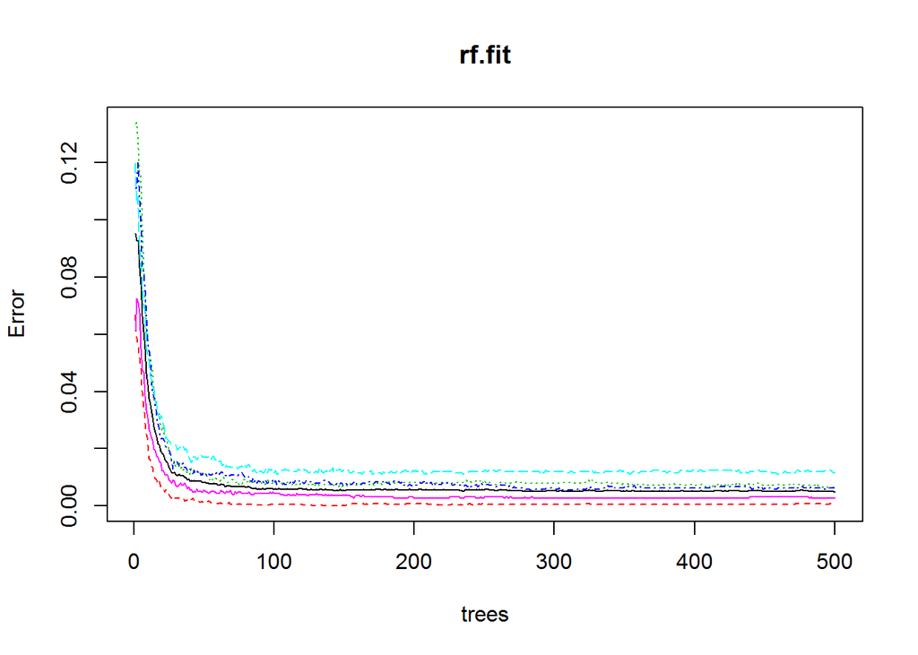

```r
plot(rf.fit)
```

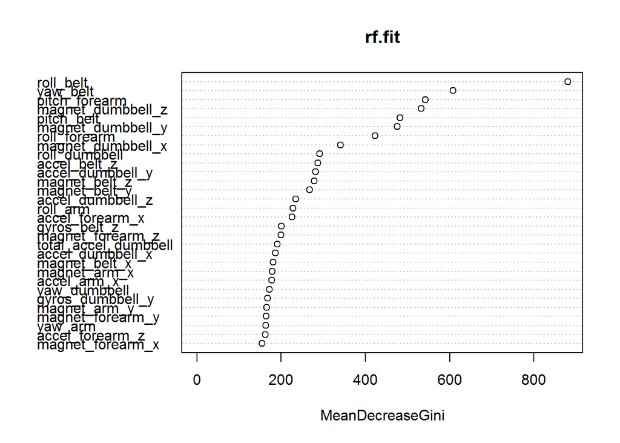

```r
varImpPlot(rf.fit)
```

#### 1) Test the small sample

```r
sample.pred<- predict(rf.fit, sampleData)
sample<-confusionMatrix(sample.pred, sampleData$classe)
```

The validation on the small sample (of size 22) has accuracy of

```r
sample$overall['Accuracy']
```

```
## Accuracy
##        1
```

So it is very possible that the prediction result on testing data will similiar close to 100%

### 2) The predict result on testing data:

```r
pred<- predict(rf.fit,testing)
print(paste(c(1:length(pred)), ": ", pred))
```

```
##  [1] "1 :  B"  "2 :  A"  "3 :  B"  "4 :  A"  "5 :  A"  "6 :  E"  "7 :  D"
##  [8] "8 :  B"  "9 :  A"  "10 :  A" "11 :  B" "12 :  C" "13 :  B" "14 :  A"
## [15] "15 :  E" "16 :  E" "17 :  A" "18 :  B" "19 :  B" "20 :  B"
```